# Лабораторная работа №6

Операционные системы

Черная С.Вю

Российский университет дружбы народов, Москва, Россия

16 марта 2024

# Информация

## Цель лабораторной работы

Приобретение практических навыков взаимодействия пользователя с системой посредством командой строки.

## Теоретическое введение

В операционной системе типа Linux взаимодействие пользователя с системой обычно осуществляется с помощью командной строки посредством построчного ввода команд. При этом обычно используется командные интерпретаторы языка shell: /bin/sh; /bin/csh; /bin/ksh.

Командой в операционной системе называется записанный по специальным правилам текст (возможно с аргументами), представляющий собой указание на выполнение какой-либо функций (или действий) в операционной системе. Обычно первым словом идёт имя команды, остальной текст — аргументы или опции, конкретизирующие действие.

Общий формат команд можно представить следующим образом: <имя_команды><разделитель><аргументы> Команда man. Команда man используется для просмотра (оперативная помощь) в диалоговом режиме руководства (manual) по основным командам операционной системы типа Linux.

Формат команды: man <команда>

Файловая система ОС типа Linux — иерархическая система каталогов, подкаталогов и файлов, которые обычно организованы и сгруппированы по функциональному признаку. Самый верхний каталог в иерархии называется корневым и обозначается символом /. Корневой каталог содержит системные файлы и другие каталоги.

В работе с командами, в качестве аргументов которых выступает путь к какому-либо каталогу или файлу, можно использовать сокращённую запись пути.

# Выполнение лабораторной работы

## Узнать полное имя домашнего каталога

Полное имя домашнего каталога можно узнать с помощью утилиты pwd(рис. 1).

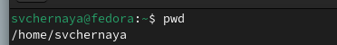

Команда pwd

## Перемещение между директориями

С помощью утилиты cd перехожу в подкаталог tmp корневого каталога(рис. 2).

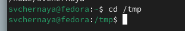

Перемещение между директориями

## Просмотр содержимого каталога

С помощью утилиты ls, пока без ключей, просматриваю содержимое каталога tmp(рис. 3).

## Просмотр содержимого каталога

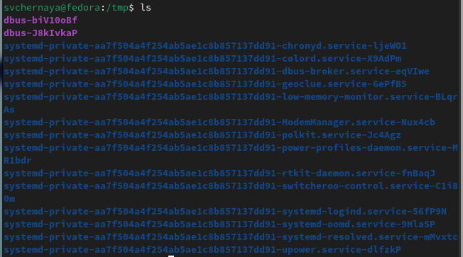

Просмотр содержимого каталога

Пробую использовать команду ls с разными опциями. Опция -l позволит увидеть дополнительную информацию о файлах в каталоге : время создания, владельца, права(рис. 4).

## Просмотр содержимого каталога

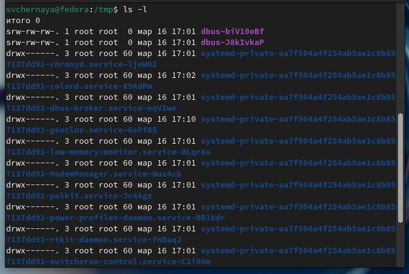

Просмотр содержимого каталога

## Просмотр содержимого каталога

Опция -а покажет скрытые файлы в каталоге(рис. 5).

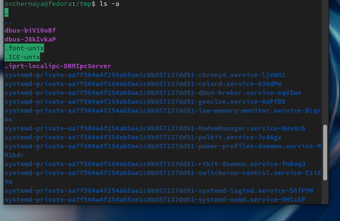

Просмотр содержимого каталога

## Поиск файла в директории

Перехожу в каталог /var/spool/ с помощью cd.Чтобы определить, есть ли в каталоге подкатлог с соответствующим именем, на самом деле, достаточно начать вводить какую-нибудь команду и имя файла и воспользоваться подсказкой tab, многие окружения рабочего стола обозначают файлы и каталоги разными цветами. Но на всякий случай воспользуемся утилитой ls с флагом -F, чтобы проверить, что мы найдем именно каталог. И да, в директории действительно есть такой каталог (рис. 6).

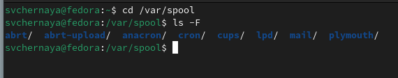

Просмотр содержимого каталога

## Изучение файлов директории

Возвращаюсь в домашний каталог, для этого достаточно ввести команду cd. Затем проверяю содержимое каталога с помощью утилиты ls, опция -l позволяет определить владельцев файлов, опция -a показывает все содержимое каталога, -F поможет определить что из содержимого каталога файл, а что каталог (рис. 7).

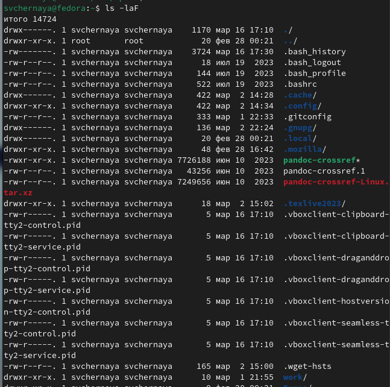

Перемещение между директориями и просмотр содержимого каталога

## Создание директорий

Создаю директорию newdir с помощью утилиты mkdir, затем проверяю, что директория создалась с помощью ls (рис. 8).

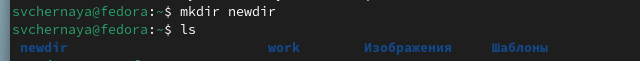

Создание директории

Создаю для каталога newdir подкаталог morefun, проверяю, что каталог собран (рис. 9).

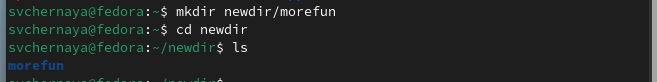

Создание директории

## Создание и удаление директорий

Чтобы создать несколько директорий одной строчкой нужно перечислить назваания директорий через пробел после утилиты mkdir (рис. 10). Проверяю, что все файлы созданы.

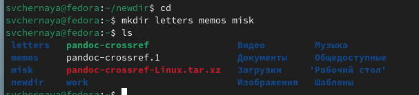

Создание директорий

Чтобы удалить несколько **пустых** директорий одной строчкой нужно перечислить назваания директорий через пробел после утилиты rmdir (рис. 11). Проверяю, что все файлы удалены.

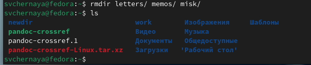

Удаление директорий

## Удаление директорий

Пытаюсь удалить newdir с помощью rm. Утилита rm по умолчанию удаляет файлы, чтобы она удалила пустую директорию нужно добавить опцию -d, но newdir не пустая дериктория, поэтому нужно добавить опцию для рекурсивного удаления -r. Использовалась утилиты без опций, поэтому каталог не был удален (рис. 12).

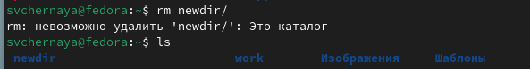

Попытка удаления директории

Удаляю директорию newdir с помощью утилиты rmdir, т.к директория не пустая, я добавляю флаг удалить рекурсивно -p, чтобы удалилсь и все подкаталоги (рис. 13).

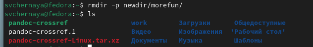

Удаление директорий

## Опции ls

С помощью команды man ls я могу прочесть документацию к команде ls(рис. 14).

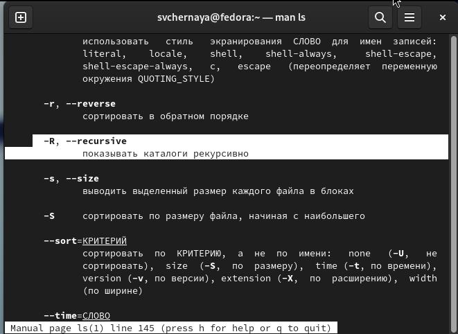

Опция для утилиты

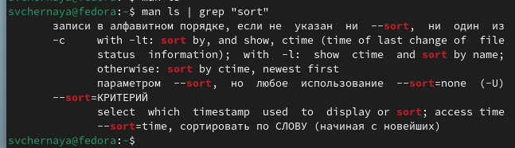

Опция утилиты

## cd

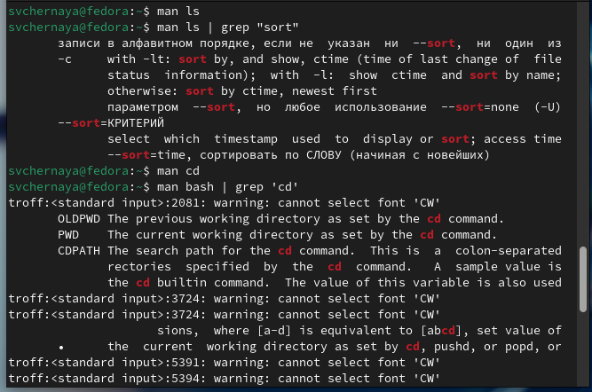

Опции команды

## pwd

С помощью man pwd узнаю описание команды pwd и ее опции (рис. 17). 1. -L - брать директорию из переменной окружения, даже если она содержит символические ссылки. 2. -P - отбрасывать все символические ссылки.

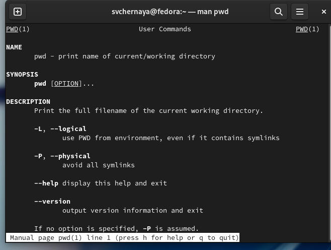

Информация о pwd

## mkdir

С помощью man mkdir узнаю описание команды mkdir и ее опции (рис. 18). 1. -m - устанавливает права доступа создаваемой директории как chmod, синтаксис тоже как у chmod. 2. -p - позволяет рекурсивно создавать директории и их подкаталоги 3. -v - выводи сообщение о созданных директориях 4. -z - установить контекст SELinux для создаваемой директории по умолчанию 5. -context - установить контекст SELinux для создаваемой директории в значении CTX

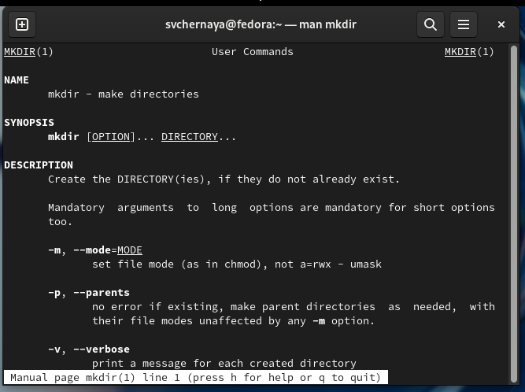

Информация о mkdir

## rmdir

С помощью man rmdir узнаю описание команды rmdir и ее опции (рис. 19). 1. –ignore-fail-on-non-empty - отменяет вывод ошибки, если каталог не пустой, просто его игнорирует 2. -p - удаляет рекурсивно каталоги, если они все содержат в себе только удаляемый каталог 3. -v - выводит сообщение о каждом удалении директории.

[figure not shown]

Информация о rmdir

## rm

С помощью man rm узнаю описание команды rm и ее опции (рис. 20). 1. -f - игнорировать несуществующие файлы или аргументы, никогда не выводить запрос на подтверждение удаления 2. -i - выводить запрос на подтверждение удаления каждого файла 3. -I - вывести запрос на подтверждение удаления один раз, для всех файлов, если удаляется больше 3-х файлов или идет рекурсивное удаление 4. –interactive - заменяет предыдущие три опции, можно выбрать одну из них. 5. –one-file-system - во время рекурсивного удаления пропускать директории из других файловых систем 6. –no-preserve-root если в качестве директории задана корневая, то считать что это обычная директория и начать удаление. 7. -r, -R - удаляет директории их содержимое рекурсивно 8. -d, –dir - удаляет пустые директории 9. -v - прописывает все действия команды

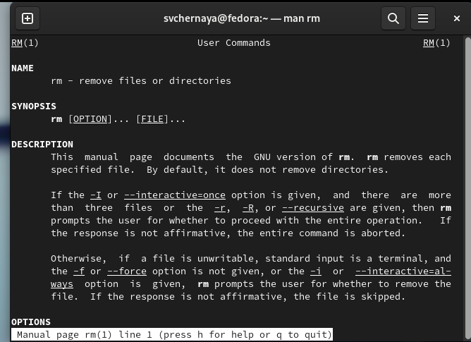

Информация о rm

## Примечание

Вывела историю команд с помощью утилиты history(рис. 21).

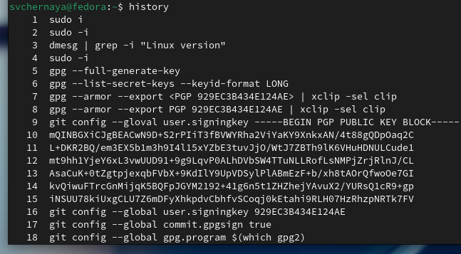

Команда history

# Выводы

Я приобрела практические навыки взаимодействия пользователя с системой посредством командной строки.